# [Python] Basic Regression

### Approximation

```python
import numpy as np
import matplotlib.pyplot as plt
%matplotlib inline
```

The main example will use the following function which is comprised of a trigonometric term and a linear term.

```python
def f(x):
    return np.sin(x) + 0.5 * x
```

```python
x = np.linspace(-2 * np.pi, 2 * np.pi, 50)
```

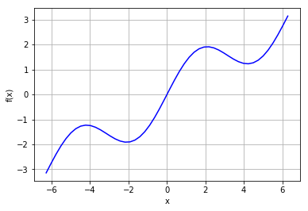

```python
plt.plot(x, f(x), 'b')
plt.grid(True)
plt.xlabel('x')
plt.ylabel('f(x)')
```

The focus is the approximation of the function over a given interval by *regression* and *interpolation*.

#### Regression

```
Parameters of polyfit function:
    x    = x coordinates (independent variable names)
    y    = y coordinates (dependent variable names)
    deg  = Degree of fitting polynomial
    full = If True, returns diagnostic information in addition
    w    = Weights to apply to y coordinates
    cov  = If True, covariance matrix is also returned
```

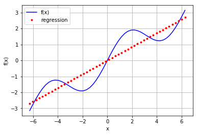

```python
# Degree

ndeg = 1

reg = np.polyfit(x, f(x), deg = ndeg)
ry  = np.polyval(reg, x)
plt.plot(x, f(x), 'b', label = 'f(x)')
plt.plot(x, ry, 'r.', label = 'regression')
plt.legend(loc = 0)
plt.grid(True)
plt.xlabel('x')
plt.ylabel('f(x)')
```

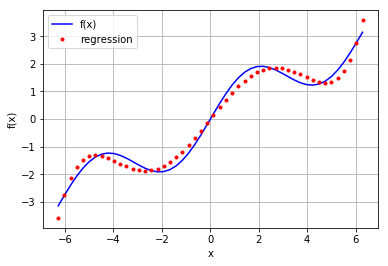

```python
ndeg = 5

reg = np.polyfit(x, f(x), deg = ndeg)
ry  = np.polyval(reg, x)
plt.plot(x, f(x), 'b', label = 'f(x)')
plt.plot(x, ry, 'r.', label = 'regression')
plt.legend(loc = 0)
plt.grid(True)
plt.xlabel('x')
plt.ylabel('f(x)')
```

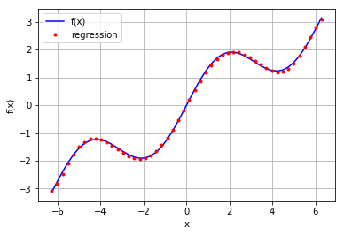

```python
ndeg = 7

reg = np.polyfit(x, f(x), deg = ndeg)
ry  = np.polyval(reg, x)
plt.plot(x, f(x), 'b', label = 'f(x)')
plt.plot(x, ry, 'r.', label = 'regression')
plt.legend(loc = 0)
plt.grid(True)
plt.xlabel('x')
plt.ylabel('f(x)')
```

Check to see how close the approximation is to the real solution with `np.allclose`.

```python
np.allclose(f(x), ry)
```

```
False
```

```python
np.sum((f(x) - ry) ** 2)/len(x)
```

```
0.0017769134759517595
```

Here the mean squared error (MSE) isn't too large over the narrow range of x values.

#### Individual basis functions

The individual basis functions have to be defined via a matrix approach (i.e., using a `NumPy ndarray` object). First, the case with monomials up to order 3.

```python
matrix = np.zeros((3 + 1, len(x)))
matrix[3, :] = x ** 3
matrix[2, :] = x ** 2
matrix[1, :] = x
matrix[0, :] = 1
```

The sublibrary `numpy.linalg` provides the function `lstsq` to solve least-squares optimization problems like the one above.

```python
reg = np.linalg.lstsq(matrix.T, f(x))[0]
```

```python
reg
```

```
array([  1.50654604e-14,   5.62777448e-01,  -1.11022302e-15,
        -5.43553615e-03])
```

To get the regression estimates we apply the `dot` function to the `reg` and `matrix` arrays.

```python
ry = np.dot(reg, matrix)
```

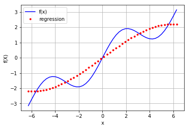

```python
plt.plot(x, f(x), 'b', label = 'f(x)')
plt.plot(x, ry, 'r.', label = 'regression')
plt.legend(loc = 0)
plt.grid(True)
plt.xlabel('x')
plt.ylabel('f(X)')
```

The resule is not really as good as expected based on the monomial approach above with `ndeg = 7`. We know that there is a `sin` part in the function. Therefore, it makes sense to include a sine function in the set of basis functions. For simplicity, we replace the highest-order monomial:

```python
matrix[3, :] = np.sin(x)
reg = np.linalg.lstsq(matrix.T, f(x))[0]
ry = np.dot(reg, matrix)
```

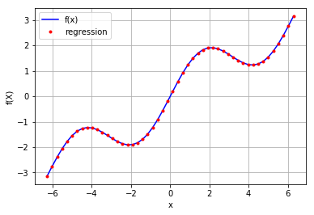

```python
plt.plot(x, f(x), 'b', label = 'f(x)')
plt.plot(x, ry, 'r.', label = 'regression')
plt.legend(loc = 0)
plt.grid(True)
plt.xlabel('x')
plt.ylabel('f(X)')
```

Now we're getting somewhere! The regression is now 'perfect' in the numerical sense.

```python
np.allclose(f(x), ry)
```

```
True
```

```python
np.sum((f(x) - ry) ** 2) / len(x)
```

```
3.3455714249939549e-31
```

```python
reg
```

```
array([  4.20040680e-16,   5.00000000e-01,   0.00000000e+00,
         1.00000000e+00])
```

#### Noisy Data

```python
xn = np.linspace(-2 * np.pi, 2 * np.pi, 50)
xn = xn + 0.15 * np.random.standard_normal(len(xn))
yn = f(xn) + 0.25 * np.random.standard_normal(len(xn))
```

The regression remains the same

```python
reg = np.polyfit(xn, yn, 7)
ry = np.polyval(reg, xn)
```

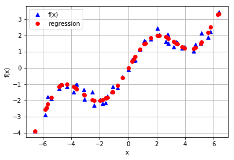

```python
plt.plot(xn, yn, 'b^', label = 'f(x)')
plt.plot(xn, ry, 'ro', label = 'regression')
plt.legend(loc = 0)
plt.grid(True)
plt.xlabel('x')
plt.ylabel('f(x)')
```

#### Unsorted Data

```python
xu = np.random.rand(50) * 4 * np.pi - 2 * np.pi
yu = f(xu)
print(xu[:10].round(2))
print(yu[:10].round(2))
```

```
[ 2.5  -0.92 -1.71  2.53  2.15 -0.07  5.47 -4.94  4.03  0.36]
[ 1.85 -1.26 -1.85  1.84  1.91 -0.11  2.01 -1.49  1.24  0.54]
```

Looking at the numbers above there appears to be no structure. As with noisy data, the regression approach does not care for the order of the observation points.

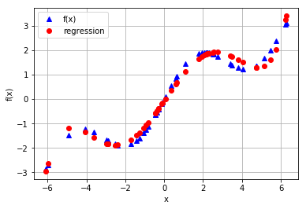

```python
reg = np.polyfit(xu, yu, 5)
ry = np.polyval(reg, xu)

plt.plot(xu, yu, 'b^', label = 'f(x)')
plt.plot(xu, ry, 'ro', label = 'regression')
plt.legend(loc = 0)
plt.grid(True)
plt.xlabel('x')
plt.ylabel('f(x)')
```

#### Multiple Dimensions

```python
def fm(x,y):
    return np.sin(x) + 0.25 * x + np.sqrt(y) + 0.05 * y ** 2
```

```python
x = np.linspace(0, 10, 20)
y = np.linspace(0, 10, 20)
X, Y = np.meshgrid(x, y)
    # generates 2-d grids out of the 1-d arrays
Z = fm(X, Y)
x = X.flatten()
y = Y.flatten()
    # yeilds 1-d arrays from the 2-d grids
```

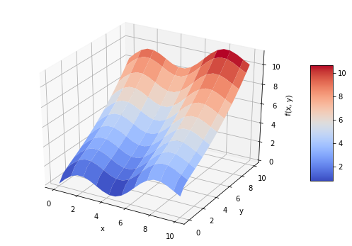

```python
from mpl_toolkits.mplot3d import Axes3D
import matplotlib as mpl

fig = plt.figure(figsize = (9, 6))
ax = fig.gca(projection='3d')
surf = ax.plot_surface(X, Y, Z, rstride = 2, cstride = 2,
                       cmap = mpl.cm.coolwarm,
                       linewidth = 0.5, antialiased = True)
ax.set_xlabel('x')
ax.set_ylabel('y')
ax.set_zlabel('f(x, y)')
fig.colorbar(surf, shrink = 0.5, aspect = 5)
```

To get good regression results we compile a set of basis functions, including both a `sin` and a `sqrt` function, which leverages our knowledge of the example function.

```python
matrix = np.zeros((len(x), 6 + 1))
matrix[:,6] = np.sqrt(y)
matrix[:,5] = np.sin(x)
matrix[:,4] = y ** 2
matrix[:,3] = x ** 2
matrix[:,2] = y
matrix[:,1] = x
matrix[:,0] = 1

import statsmodels.api as sm

model = sm.OLS(fm(x, y), matrix).fit()
```

```python
model.rsquared
```

```
1.0
```

```python
a = model.params
a
```

[output not shown]

```python
def reg_func(a,x,y):
    f6 = a[6] * np.sqrt(y)
    f5 = a[5] * np.sin(x)
    f4 = a[4] * y ** 2
    f3 = a[3] * x ** 2
    f2 = a[2] * y
    f1 = a[1] * x
    f0 = a[0] * 1
    return(f6 + f5 + f4 + f3 + f2 + f1 + f0)
```

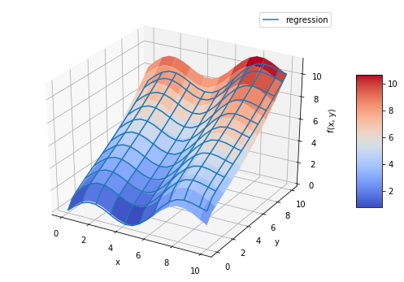

```python
RZ = reg_func(a, X, Y)

fig = plt.figure(figsize = (9, 6))
ax = fig.gca(projection = '3d')
surf1 = ax.plot_surface(X, Y, Z, rstride=2, cstride=2,
                       cmap = mpl.cm.coolwarm, linewidth = 0.5,
                       antialiased = True)
surf2 = ax.plot_wireframe(X, Y, RZ, rstride = 2, cstride = 2,
                         label = 'regression')
ax.set_xlabel('x')
ax.set_ylabel('y')
ax.set_zlabel('f(x, y)')
ax.legend()
fig.colorbar(surf, shrink = 0.5, aspect=5)
```